# computer vision

gaurav sood

## Building Blocks and Main Varietals

- Building Blocks
  - Convolutions (Filters)
  - Pooling
  - Upsampling
  - Selective search
- Main Varietals
  - Object Detection
  - Image Segmentation
  - Instance Segmentation

## Object Detection

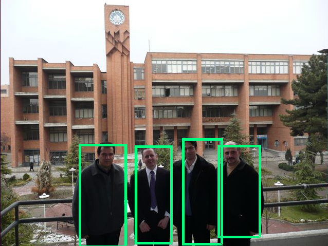

## Semantic Segmentation

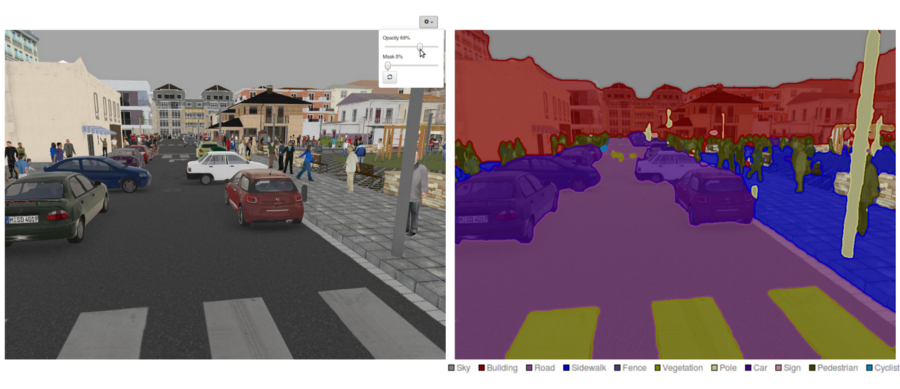

## Instance Segmentation

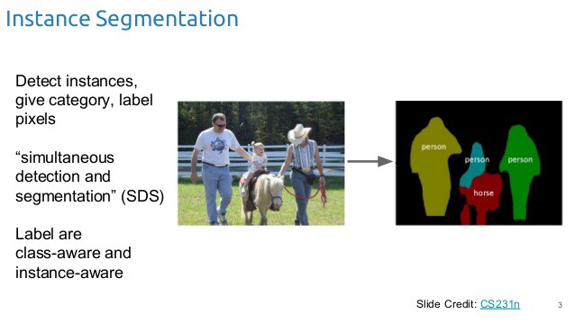

## Why Do Instance Segmentation?

- Driving: is the car ahead braking?
  - To answer that, you need to track the car so that you can estimate change in speed
    - If you lose which car, your estimate of change in speed would be garbled
  - Instance segmentation can distinguish vehicles within a frame; tracking associates them across frames.

## A Brief Aside: How to build generalizable models?

- Classification
  - Inter-class variation
    - Cat images, Dog images
  - Intra-class variation:
    - How many different types of cats exist
  - Lots of diff. classes
    - It can encourage richer representations, but does not prevent shortcut learning

## Loss Function for Object Detection

- Localization Loss
  - Bounding box
  - (x, y), width, height
  - Coordinate convention depends on the detector. YOLO v1 predicts box centers relative to their grid cell and width/height relative to the image.
  - Loss function:
    - $(x - \hat{x})^2$, $(y - \hat{y})^2$
    - $(\sqrt{w} - \sqrt{\hat{w}})^2$ (YOLO)
      - to reduce the relative influence of large-box size errors on localization loss
- Classification Loss
- Net Loss
  - Localization Loss + Objectness Loss + Classification Loss
  - You can weight the losses

## YOLO v1 loss

For $S^2$ cells and $B$ boxes per cell, let $I_{ij}$ indicate the box responsible for a ground-truth object and $I_i$ indicate an occupied cell. Hats denote predictions. For a responsible box, $C_{ij}$ is its IoU with the ground-truth box; non-responsible boxes have target 0.

$$L=\lambda_{\rm coord}L_{\rm loc}
+L_{\rm conf}+L_{\rm cls}.$$

$$L_{\rm
loc}=\sum_{i=1}^{S^2}\sum_{j=1}^{B}I_{ij}
\left[(x_{ij}-\hat x_{ij})^2+(y_{ij}-\hat y_{ij})^2
+(\sqrt{w_{ij}}-\sqrt{\hat w_{ij}})^2
+(\sqrt{h_{ij}}-\sqrt{\hat h_{ij}})^2\right].$$

## YOLO v1: confidence and classes

$$L_{\rm
conf}=\sum_{i=1}^{S^2}\sum_{j=1}^{B}
[I_{ij}+\lambda_{\rm noobj}(1-I_{ij})](C_{ij}-\hat
C_{ij})^2.$$

$$L_{\rm
cls}=\sum_{i=1}^{S^2}I_i\sum_{c\in\mathrm{classes}}
[p_i(c)-\hat p_i(c)]^2.$$

Here $p_i(c)$ is the conditional class probability for an occupied cell. This is the YOLO v1 loss. See [Redmon et al. (2016)](https://www.cv-foundation.org/openaccess/content_cvpr_2016/papers/Redmon_You_Only_Look_CVPR_2016_paper.pdf).

## Segmenting Images

[figure not shown]

https://ai.stanford.edu/~syyeung/cvweb/tutorial1.html

## Filters

A sharpening kernel (applied once):
$$\begin{bmatrix}0&-1&0\\-1&5&-1\\0&-1&0\end{bmatrix}.$$

## Convolutions

Slide a kernel over the image and sum element-wise products in each window. CNN libraries usually implement cross-correlation; mathematical convolution also flips the kernel.

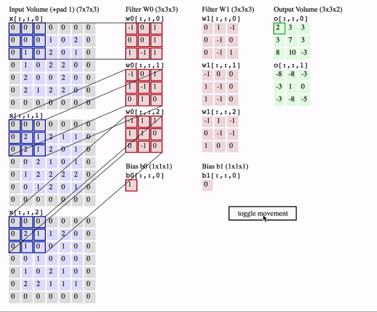

https://cs231n.github.io/convolutional-networks/

## (Max) Pooling

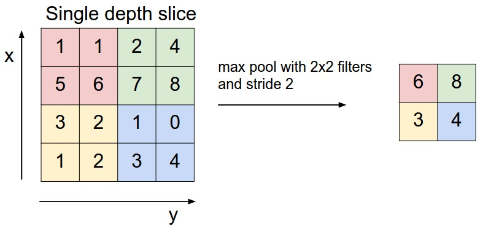

https://cs231n.github.io/convolutional-networks/

- Backward pass?

## Backward pass

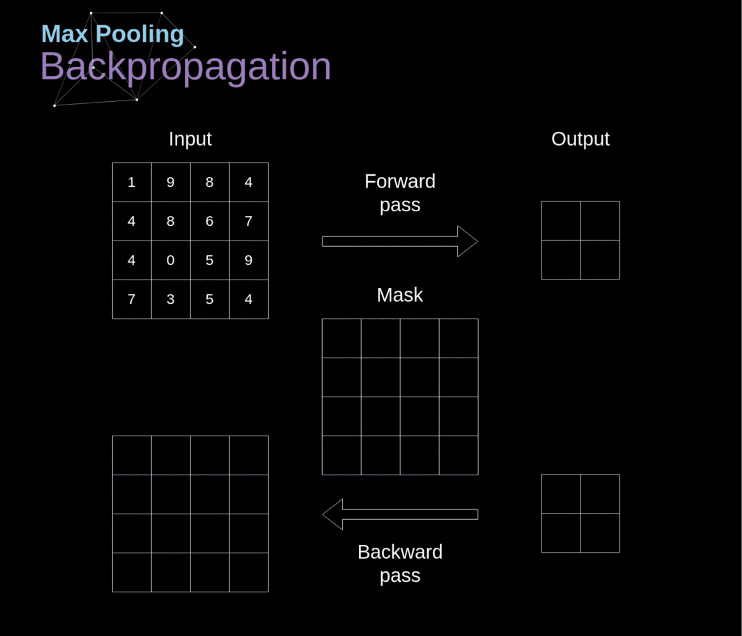

https://towardsdatascience.com/gentle-dive-into-math-behind-convolutional-neural-networks-79a07dd44cf9

## Upsampling

- Nearest neighbor interpolation
- Bi-linear interpolation, etc.

  $$\begin{align}
  f(x,y_{1}) \approx \frac{x_{2}-x}{x_{2}-x_{1}} f(Q_{11}) +
  \frac{x-x_{1}}{x_{2}-x_{1}} f(Q_{21})\\
  f(x,y_{2}) \approx \frac{x_{2}-x}{x_{2}-x_{1}} f(Q_{12}) +
  \frac{x-x_{1}}{x_{2}-x_{1}} f(Q_{22})
  \end{align}$$

  Next, interpolate in the y-direction:

  $$\begin{align}
  f(x,y) \approx \frac{y_{2}-y}{y_{2}-y_{1}} f(x,y_{1}) + \frac
  {y-y_{1}}{y_{2}-y_{1}} f(x,y_{2})
  \end{align}$$

## Transposed Convolution

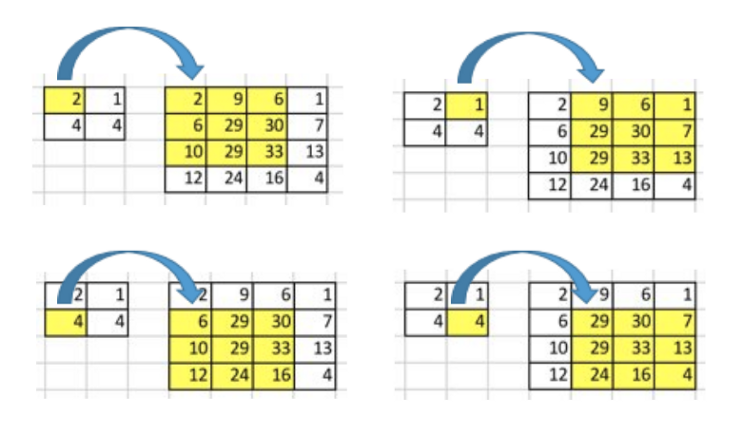

https://naokishibuya.medium.com/up-sampling-with-transposed-convolution-9ae4f2df52d0

## Evaluation Criteria

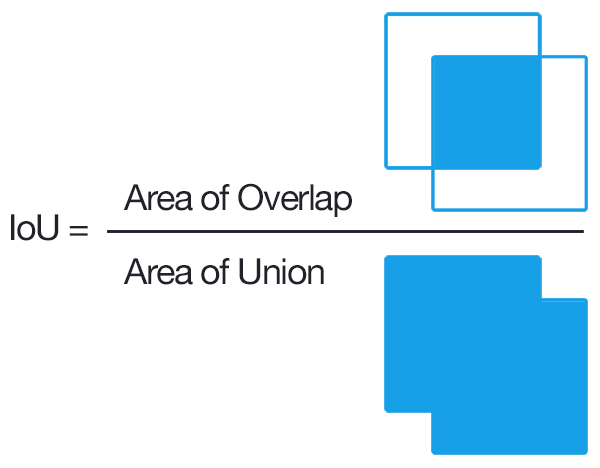

## Thresholding IoU

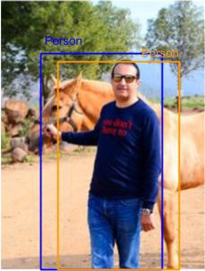

## Mean average precision

- Rank detections by confidence within each class.
- At a stated IoU threshold, match predictions to ground-truth boxes one-to-one; duplicate detections are false positives.
- Vary the confidence threshold to obtain a precision-recall curve.
- Average precision (AP) summarizes precision across recall levels; interpolation rules depend on the benchmark.
- Mean AP averages AP over classes. COCO also averages across specified IoU thresholds; report the benchmark convention.
- AP may be reported in [0, 1] or as a percentage.

## Segmenting Images

- Image as graph:
  - pixel = vertex
  - edge = connection between neighboring pixels
    - At most 8 neighboring pixels in an 8-connected grid
    - weight = dissimilarity between the pixels
- Measuring Distances
  - Internal Difference: $Int(C) = \max_{e\in MST(C, E)} w(e)$
  - Difference between two components: $Dif(C_1, C_2) = \min_{v_i \in C_1, v_j \in C_2, (v_i, v_j) \in E} w(v_i, v_j)$
  - Minimum internal difference: $MInt(C_1,C_2)=\min(Int(C_1)+\tau(C_1),Int(C_2)+\tau(C_2))$ where $\tau(C)=k/|C|$, with scale parameter $k\geq0$.

For a singleton, $Int(C)=0$. If no edge joins two components, their difference is infinite.

## Segmenting Images (Contd.)

- Segmentation
  - Partition vertices into multiple connected components
  - Evidence for a boundary between two components if $D(C_1, C_2) = \begin{cases} \text{True} & \text{ if } Dif(C_1, C_2) > MInt(C_1, C_2) \\ \text{False} & \text{ otherwise} \end{cases}$
- [Felzenszwalb’s Algorithm](https://cs.brown.edu/people/pfelzens/papers/seg-ijcv.pdf)
  - Sort edges by weight in ascending order
  - Start with n components
  - Pick the kth edge
  - If the vertices at the ends of the edge are in the same component, do nothing
  - If they are different, merge if $w(v_i, v_j) \leq MInt(C_i^{k-1}, C_j^{k-1})$

## Selective Search

1. Segment images
2. Greedily group regions together till all image is one region
   - Calculate similarity with neighbors
   - Combine with the most similar region
   - Calculate new similarity scores
3. Practical stuff:
- Define similarity via color, texture, shape, etc.
- Bias for merging smaller regions first.